# Lab 1 Gapminder Data Visualization

Github Repository: https://github.com/jonathan-cleave/GSB-544-.git

# Task 1

## 1. Identify aesthetics

Income is the indepdent variable, Life expectancy is the depdentant variable and it is using a bubble chart to map each country based on 2010. The x-axis is using a log scale, but the data is not transformed. Also, the size of the bubbles is dependant on the population of each country.

## 2. Importing the dataset

```python
import pandas as pd
import numpy as np
import matplotlib.pyplot as plt
from plotnine import ggplot, geom_point, aes, geom_boxplot
```

```python
# loading csv
q1 = pd.read_csv("C:/Users/jonat/Documents/Calpoly MSBA/Fall/Machine Learning 544/Data/q1data.csv")
```

```python
#look at data types
q1.dtypes
```

```
income               float64
life_exp             float64
population           float64
year                   int64
country               object
four_regions          object
six_regions           object
eight_regions         object
world_bank_region     object
dtype: object
```

## 3. Recreating the plot

```python
# filter to 2010
q1_2010 = q1.query("year == 2010")
q1_2010
```

|  | income | life_exp | population | year | country | four_regions | six_regions | eight_regions | world_bank_region |
| --- | --- | --- | --- | --- | --- | --- | --- | --- | --- |
| 0 | 1910.0 | 61.0 | 29200000.0 | 2010 | Afghanistan | asia | south_asia | asia_west | South Asia |
| 1 | 11100.0 | 78.1 | 2950000.0 | 2010 | Albania | europe | europe_central_asia | europe_east | Europe & Central Asia |
| 2 | 11100.0 | 74.7 | 36000000.0 | 2010 | Algeria | africa | middle_east_north_africa | africa_north | Middle East & North Africa |
| 3 | 46900.0 | 81.9 | 84500.0 | 2010 | Andorra | europe | europe_central_asia | europe_west | Europe & Central Asia |
| 4 | 7680.0 | 60.8 | 23400000.0 | 2010 | Angola | africa | sub_saharan_africa | africa_sub_saharan | Sub-Saharan Africa |
| ... | ... | ... | ... | ... | ... | ... | ... | ... | ... |
| 192 | 20400.0 | 75.4 | 28400000.0 | 2010 | Venezuela | americas | america | america_south | Latin America & Caribbean |
| 193 | 5350.0 | 73.3 | 88000000.0 | 2010 | Vietnam | asia | east_asia_pacific | east_asia_pacific | East Asia & Pacific |
| 194 | 4700.0 | 67.8 | 23200000.0 | 2010 | Yemen | asia | middle_east_north_africa | asia_west | Middle East & North Africa |
| 195 | 3200.0 | 57.5 | 13600000.0 | 2010 | Zambia | africa | sub_saharan_africa | africa_sub_saharan | Sub-Saharan Africa |
| 196 | 2560.0 | 54.4 | 12700000.0 | 2010 | Zimbabwe | africa | sub_saharan_africa | africa_sub_saharan | Sub-Saharan Africa |

197 rows × 9 columns

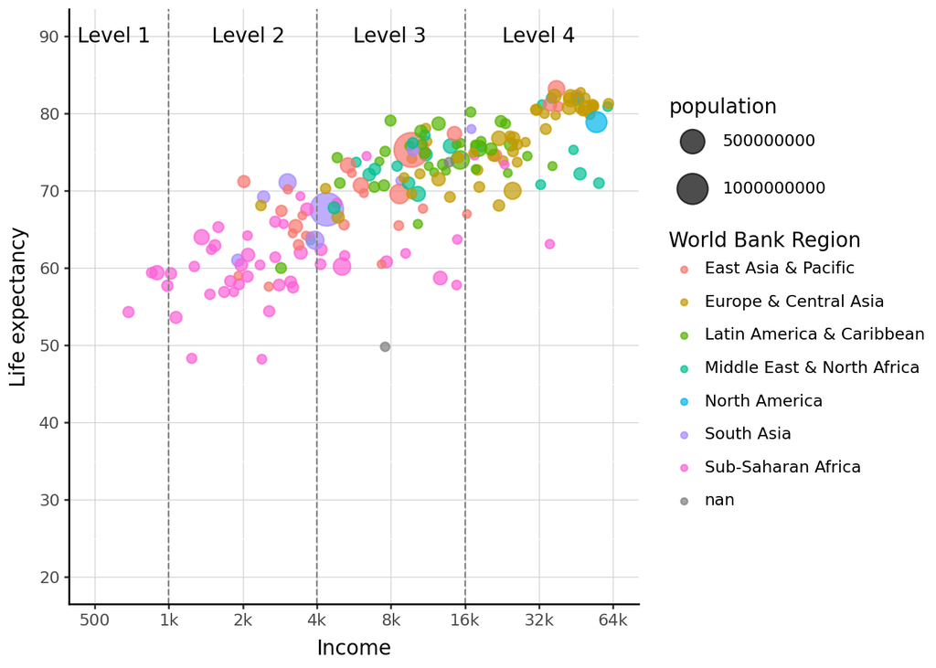

```python
# Recreate plot
from plotnine import *
import numpy as np

(
    ggplot(q1_2010, aes(x="income", y="life_exp"))
    + geom_point(
        aes(size="population", color="world_bank_region"),alpha = 0.7)
    + scale_size(range=(2,10))
    + scale_x_log10(
    limits=(500, 64000),
    breaks=[500, 1000, 2000, 4000, 8000, 16000, 32000, 64000],
    labels=lambda v: [f"{int(round(x))}" if x < 1000 else f"{int(round(x/1000))}k" for x in v]
    )
    + scale_y_continuous(
        limits=(20, 90),
        breaks=range(20, 91, 10)
    )
    + labs(
        x="Income",
        y="Life expectancy",
        color="World Bank Region")
    + theme(
        panel_background=element_rect(fill="white", color=None),   # white background
        panel_grid_major=element_line(color="lightgrey", size=0.5), # grey major grid lines
        axis_line=element_line(color="black")
    )

    # Vertical divider lines for income thresholds
    + geom_vline(xintercept=[1000, 4000, 16000], linetype="dashed", color="grey")

    # Labels above the dividers
    + annotate("text", x=600, y=90, label="Level 1", ha="center")
    + annotate("text", x=2100, y=90, label="Level 2", ha="center")
    + annotate("text", x=7900, y=90, label="Level 3", ha="center")
    + annotate("text", x=31900, y=90, label="Level 4", ha="center")
)
```

## 4. Bar Chart Geometry

I created a bar chart which shows the average income by region using the data, this is a broad overview and is not as focused as the bubble chart, however it compares each region more clearly.

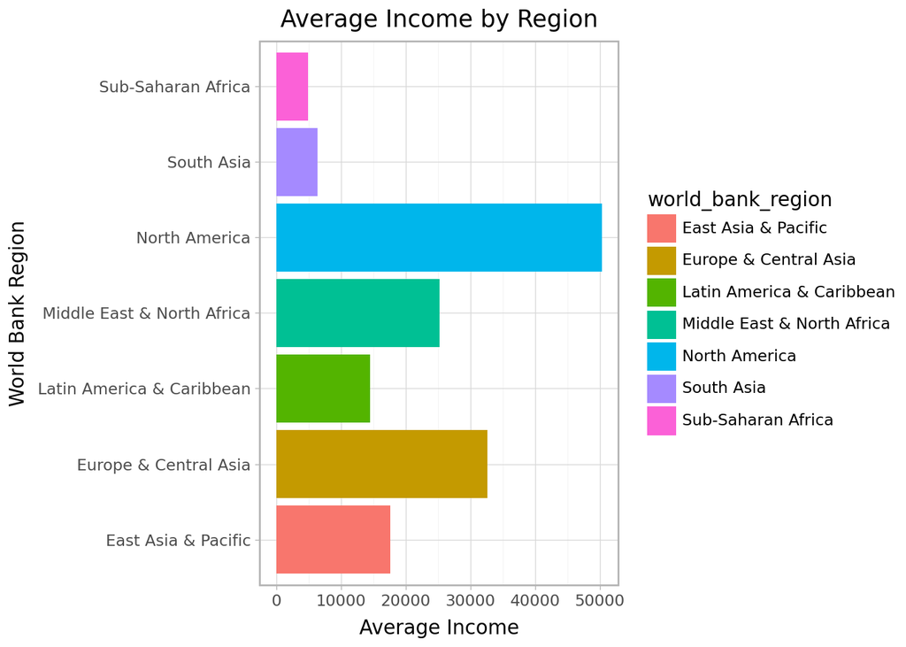

```python
# Create new chart
from plotnine import *
import numpy as np

income_avg = (
    q1_2010
    .dropna(subset=["world_bank_region"])
    .groupby("world_bank_region", as_index=False)["income"].mean()
)

(
    ggplot(income_avg, aes(x="world_bank_region",y="income",fill="world_bank_region"))
    + geom_col()
    +coord_flip()
    +labs(x="World Bank Region", y="Average Income", title = "Average Income by Region")
    +theme_light()
)
```

# Task 2

## 1. Identify aesthics

This chart displays the exports on the x-axis to imports on the y as a percent of GDP by world region with the data being set to 1997. This visualization is not using a log scale for the x axis. Energy use is the bubble size.

## 2. Import data

```python
# loading csv
q2 = pd.read_csv("C:/Users/jonat/Documents/Calpoly MSBA/Fall/Machine Learning 544/Data/q2data.csv")
```

```python
q2
```

|  | imports | exports | energy | year | country | four_regions | six_regions | eight_regions | world_bank_region |
| --- | --- | --- | --- | --- | --- | --- | --- | --- | --- |
| 0 | NaN | NaN | NaN | 1997 | Afghanistan | asia | south_asia | asia_west | South Asia |
| 1 | 36.7 | 11.5 | 427 | 1997 | Albania | europe | europe_central_asia | europe_east | Europe & Central Asia |
| 2 | 22.5 | 22.6 | 825 | 1997 | Algeria | africa | middle_east_north_africa | africa_north | Middle East & North Africa |
| 3 | NaN | NaN | NaN | 1997 | American Samoa | NaN | NaN | NaN | NaN |
| 4 | NaN | NaN | 434 | 1997 | Angola | africa | sub_saharan_africa | africa_sub_saharan | Sub-Saharan Africa |
| ... | ... | ... | ... | ... | ... | ... | ... | ... | ... |
| 201 | 52.2 | 44.8 | 340 | 1997 | Vietnam | asia | east_asia_pacific | east_asia_pacific | East Asia & Pacific |
| 202 | NaN | NaN | NaN | 1997 | Virgin Islands (U.S.) | NaN | NaN | NaN | NaN |
| 203 | NaN | NaN | 241 | 1997 | Yemen | NaN | NaN | NaN | NaN |
| 204 | 31.6 | 24.6 | 617 | 1997 | Zambia | africa | sub_saharan_africa | africa_sub_saharan | Sub-Saharan Africa |
| 205 | 45.1 | 43.4 | 845 | 1997 | Zimbabwe | africa | sub_saharan_africa | africa_sub_saharan | Sub-Saharan Africa |

206 rows × 9 columns

```python
#look at data types
q2.dtypes
```

```
imports              float64
exports              float64
energy                object
year                   int64
country               object
four_regions          object
six_regions           object
eight_regions         object
world_bank_region     object
dtype: object
```

## 3. Recreate Plot

```python
# filter to 1997
q2_1997 = q2.query("year == 1997")
q2_1997
```

|  | imports | exports | energy | year | country | four_regions | six_regions | eight_regions | world_bank_region |
| --- | --- | --- | --- | --- | --- | --- | --- | --- | --- |
| 0 | NaN | NaN | NaN | 1997 | Afghanistan | asia | south_asia | asia_west | South Asia |
| 1 | 36.7 | 11.5 | 427 | 1997 | Albania | europe | europe_central_asia | europe_east | Europe & Central Asia |
| 2 | 22.5 | 22.6 | 825 | 1997 | Algeria | africa | middle_east_north_africa | africa_north | Middle East & North Africa |
| 3 | NaN | NaN | NaN | 1997 | American Samoa | NaN | NaN | NaN | NaN |
| 4 | NaN | NaN | 434 | 1997 | Angola | africa | sub_saharan_africa | africa_sub_saharan | Sub-Saharan Africa |
| ... | ... | ... | ... | ... | ... | ... | ... | ... | ... |
| 201 | 52.2 | 44.8 | 340 | 1997 | Vietnam | asia | east_asia_pacific | east_asia_pacific | East Asia & Pacific |
| 202 | NaN | NaN | NaN | 1997 | Virgin Islands (U.S.) | NaN | NaN | NaN | NaN |
| 203 | NaN | NaN | 241 | 1997 | Yemen | NaN | NaN | NaN | NaN |
| 204 | 31.6 | 24.6 | 617 | 1997 | Zambia | africa | sub_saharan_africa | africa_sub_saharan | Sub-Saharan Africa |
| 205 | 45.1 | 43.4 | 845 | 1997 | Zimbabwe | africa | sub_saharan_africa | africa_sub_saharan | Sub-Saharan Africa |

206 rows × 9 columns

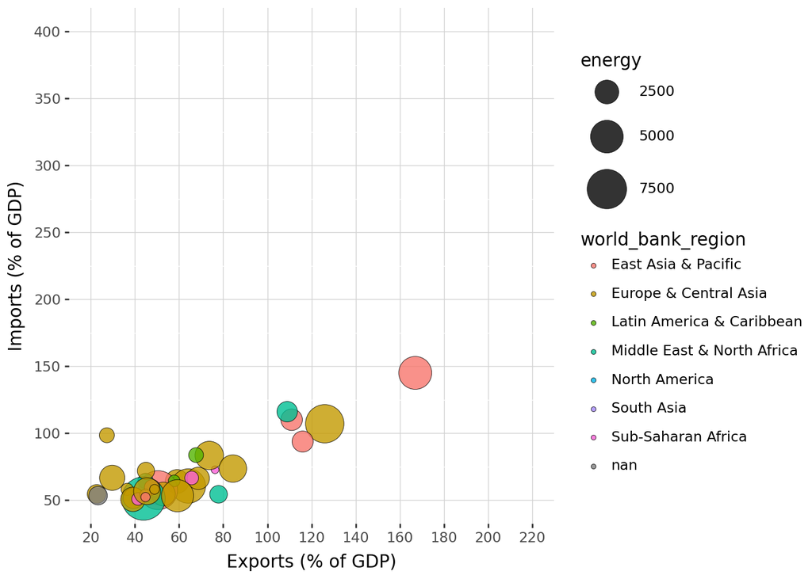

```python
# recreate plot

q2_1997["energy"]=pd.to_numeric(q2_1997["energy"], errors="coerce")

(
ggplot(q2_1997, aes(x="exports", y="imports"))

+ geom_point(aes(size="energy",fill="world_bank_region"),
    color="black",
    stroke=0.2,
    alpha=.8,
)
+ scale_size(range=(1,15))
+ labs(x="Exports (% of GDP)", y="Imports (% of GDP)", color="World Bank Region")
+ scale_x_continuous(
        limits=(20, 220),
        breaks=range(20, 221, 20)
)
+ scale_y_continuous(
        limits=(50, 400),
        breaks=range(50, 401, 50)
)

+ theme(
        panel_background=element_rect(fill="white", color=None),   # white background
        panel_grid_major=element_line(color="lightgrey", size=0.5), # grey major grid lines
)
)
```

## 4. 2D Heatmap

Using geom_bin I created a 2D histogram heatmap showing Exports vs Imports which can quickly show where countries cluster in tke Exports/Imports plane and is able to reduce the overalpping of bubbles. However it doesn’t show the country region like the bubble plot.

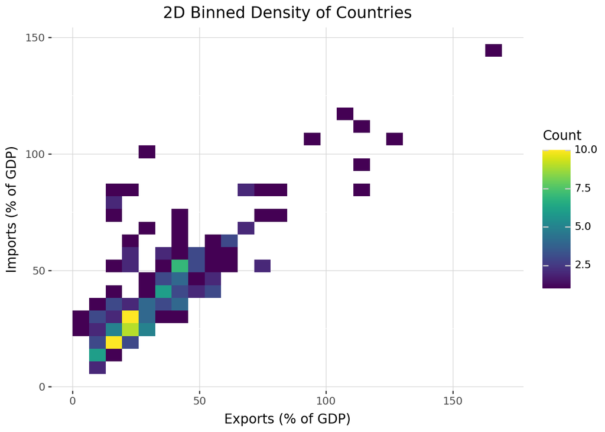

```python
from plotnine import *
(
    ggplot(q2_1997,aes(x="exports", y="imports"))
    + geom_bin2d(bins=25)
    + scale_fill_continuous(name="Count")
    + labs(x="Exports (% of GDP)", y="Imports (% of GDP)",
        title="2D Binned Density of Countries")

    + theme(
        panel_background=element_rect(fill="white", color=None),   # white background
        panel_grid_major=element_line(color="lightgrey", size=0.5), # grey major grid lines
)
)
```

# Task 3

## 1. Identify aesthetics

This chart displays the Indivdiuals using the internet on the x axis as a percent of population to the GDP per capital on the y axis for all countries in 2001. It seems there is log scaling on the y axis to make the GDP go from 200 to 100k. The bubbles size are based on income.

## 2. Import data

```python
# loading csv
q3 = pd.read_csv("C:/Users/jonat/Documents/Calpoly MSBA/Fall/Machine Learning 544/Data/q3data.csv")
```

```python
q3
```

|  | internet_users | gdp | income | year | country | four_regions | six_regions | eight_regions | world_bank_region |
| --- | --- | --- | --- | --- | --- | --- | --- | --- | --- |
| 0 | 0.00456 | 330.0 | 1190.0 | 2001 | Afghanistan | asia | south_asia | asia_west | South Asia |
| 1 | 0.39000 | 2570.0 | 6780.0 | 2001 | Albania | europe | europe_central_asia | europe_east | Europe & Central Asia |
| 2 | 1.59000 | 3770.0 | 9230.0 | 2001 | Algeria | africa | middle_east_north_africa | africa_north | Middle East & North Africa |
| 3 | NaN | 10500.0 | NaN | 2001 | American Samoa | NaN | NaN | NaN | NaN |
| 4 | 11.30000 | 42600.0 | 35600.0 | 2001 | Andorra | europe | europe_central_asia | europe_west | Europe & Central Asia |
| ... | ... | ... | ... | ... | ... | ... | ... | ... | ... |
| 210 | 1.85000 | 847.0 | 3270.0 | 2001 | Vietnam | asia | east_asia_pacific | east_asia_pacific | East Asia & Pacific |
| 211 | 27.50000 | 36700.0 | NaN | 2001 | Virgin Islands (U.S.) | NaN | NaN | NaN | NaN |
| 212 | 0.51900 | 1190.0 | 4940.0 | 2001 | Yemen | asia | middle_east_north_africa | asia_west | Middle East & North Africa |
| 213 | 0.47800 | 991.0 | 2080.0 | 2001 | Zambia | africa | sub_saharan_africa | africa_sub_saharan | Sub-Saharan Africa |
| 214 | 1.10000 | 1330.0 | 3190.0 | 2001 | Zimbabwe | africa | sub_saharan_africa | africa_sub_saharan | Sub-Saharan Africa |

215 rows × 9 columns

```python
#look at data types
q3.dtypes
```

```
internet_users       float64
gdp                  float64
income               float64
year                   int64
country               object
four_regions          object
six_regions           object
eight_regions         object
world_bank_region     object
dtype: object
```

## 3. Recreate Plot

```python
# filter to 2001
q3_2001 = q3.query("year == 2001")
q3_2001
```

|  | internet_users | gdp | income | year | country | four_regions | six_regions | eight_regions | world_bank_region |
| --- | --- | --- | --- | --- | --- | --- | --- | --- | --- |
| 0 | 0.00456 | 330.0 | 1190.0 | 2001 | Afghanistan | asia | south_asia | asia_west | South Asia |
| 1 | 0.39000 | 2570.0 | 6780.0 | 2001 | Albania | europe | europe_central_asia | europe_east | Europe & Central Asia |
| 2 | 1.59000 | 3770.0 | 9230.0 | 2001 | Algeria | africa | middle_east_north_africa | africa_north | Middle East & North Africa |
| 3 | NaN | 10500.0 | NaN | 2001 | American Samoa | NaN | NaN | NaN | NaN |
| 4 | 11.30000 | 42600.0 | 35600.0 | 2001 | Andorra | europe | europe_central_asia | europe_west | Europe & Central Asia |
| ... | ... | ... | ... | ... | ... | ... | ... | ... | ... |
| 210 | 1.85000 | 847.0 | 3270.0 | 2001 | Vietnam | asia | east_asia_pacific | east_asia_pacific | East Asia & Pacific |
| 211 | 27.50000 | 36700.0 | NaN | 2001 | Virgin Islands (U.S.) | NaN | NaN | NaN | NaN |
| 212 | 0.51900 | 1190.0 | 4940.0 | 2001 | Yemen | asia | middle_east_north_africa | asia_west | Middle East & North Africa |
| 213 | 0.47800 | 991.0 | 2080.0 | 2001 | Zambia | africa | sub_saharan_africa | africa_sub_saharan | Sub-Saharan Africa |
| 214 | 1.10000 | 1330.0 | 3190.0 | 2001 | Zimbabwe | africa | sub_saharan_africa | africa_sub_saharan | Sub-Saharan Africa |

215 rows × 9 columns

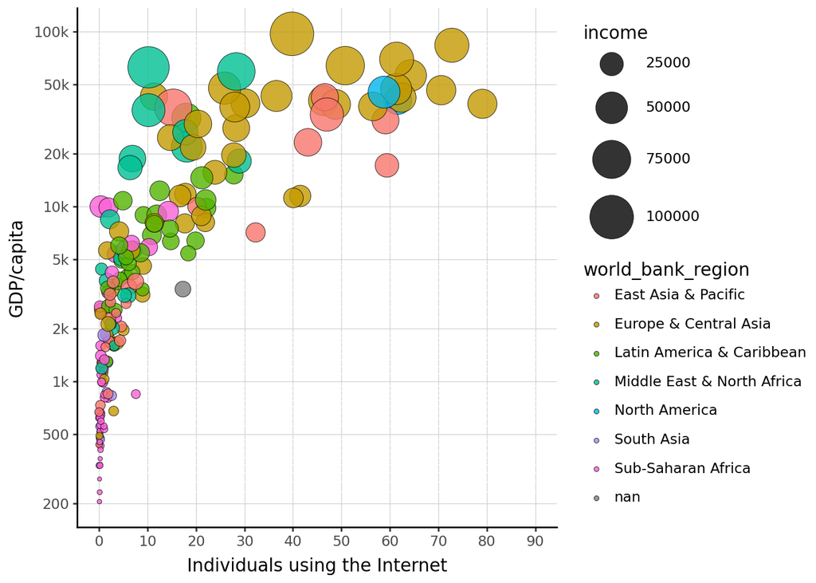

```python
# recreate plot

(
ggplot(q3_2001, aes(x="internet_users", y="gdp"))

+ geom_point(aes(size="income",fill="world_bank_region"),
    color="black",
    stroke=0.2,
    alpha=.8,
)
+ scale_size(range=(1,15))
+ labs(x="Individuals using the Internet", y="GDP/capita", color="World Bank Region")
+ scale_x_continuous(
        limits=(0, 90),
        breaks=range(0, 91, 10)
)
+ scale_y_log10(
        limits=(200, 100000),
    breaks=[200, 500, 1000, 2000, 5000, 10000, 20000, 50000, 100000],
    labels=lambda v: [f"{int(round(x))}" if x < 1000 else f"{int(round(x/1000))}k" for x in v]
)

+ theme(
        panel_background=element_rect(fill="white", color=None),   # white background
        panel_grid_major=element_line(color="lightgrey", size=0.5), # grey major grid lines
         axis_line=element_line(color="black")
)
)
```

## 4. Stacked Area Chart

Using geom_area I created a stack area chart that shows the internet users arranged into bins by the number of countries to show each region’s individuals using the internet at different bin sizes. It’s a poor fit because stacked areas imply a continuous trend between discrete bins, and the stacking hides comparisons—only the bottom region has a common baseline, so middle/top regions are hard to read.

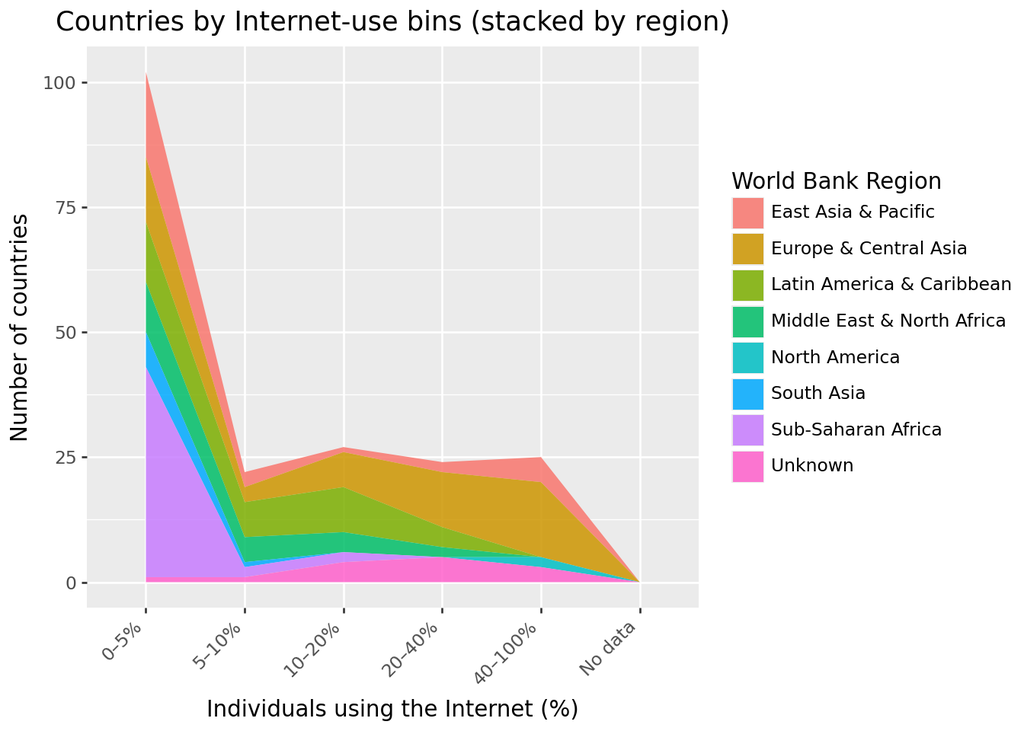

```python
q = q3_2001.copy()
q["internet_users"] = pd.to_numeric(q["internet_users"], errors="coerce")
q["world_bank_region"] = q["world_bank_region"].fillna("Unknown")
q = q[(q["internet_users"] >= 0) & (q["internet_users"] <= 100)]

bins   =  [0, 5, 10, 20, 40, 100]
labels = ["0–5%", "5–10%", "10–20%", "20–40%", "40–100%"]
q["internet_bin"] = pd.cut(q["internet_users"], bins=bins, labels=labels,
                           include_lowest=True, right=True)
q["internet_bin"] = q["internet_bin"].cat.add_categories(["No data"])
q.loc[q["internet_bin"].isna(), "internet_bin"] = "No data"

counts = (q.groupby(["internet_bin", "world_bank_region"], dropna=False)
            .size()
            .reset_index(name="n"))

counts["internet_bin"] = pd.Categorical(counts["internet_bin"],
                                        ["0–5%", "5–10%", "10–20%", "20–40%", "40–100%", "No data"],
                                        ordered=True)

(
    ggplot(counts, aes("internet_bin", "n", fill="world_bank_region",
                       group="world_bank_region"))
    + geom_area(position="stack", alpha=0.85)
    + labs(x="Individuals using the Internet (%)", y="Number of countries",
           fill="World Bank Region",
           title="Countries by Internet-use bins (stacked by region)")
    + theme(axis_text_x=element_text(rotation=45, ha="right"))
)
```